# r-markdown-cheatsheet

## R Markdown

R Markdown is a format for writing reproducible reports in R. It uses a simple formatting syntax which can be used to mix text, code, images or plots and to write output in HTML, PDF, and Microsoft Word documents.

## Markdown syntax

`This is a plain text line without any formatting.` This is a plain text line without any formatting.

`*This text is in italics*` *This text is in italics*

`_as is this text_` *as is this text*

`**This text is in bold**` **This text is in bold**

`__as is this text__` **as is this text**

`This text shows ^superscript^` This text shows <sup>superscript</sup>

`This text is ~~strikethrough~~` This text is strikethrough

Mix html tags e.g. a horizontal rule here with <hr> </hr>tag:

`End a line with two spaces to start a new paragraph.`  
End a line with two spaces to start a new paragraph.

`# Header 1 format`

# Header 1 format

`## Header 2 format`

## Header 2 format

`### Header 3 format`

### Header 3 format

`#### Header 4 format`

#### Header 4 format

`##### Header 5 format`

##### Header 5 format

`###### Header 6 format`

###### Header 6 format

`[Link to my Github page](github.com/dnafrance)` Link to my Github page

Embed code with knitr syntax. R executes code and displays the output.  
`` Simple arithmetic with inline code: ` r 3 + 7 ` `` Simple arithmetic with inline code: 10

` Display code format with backticks ` `Display code format with backticks`

`> block quote`

> block quote

`* unordered list`  
`* item 2`  
`+ sub-item 1`  
`+ sub-item 2`

- unordered list
- item 2
  - sub-item 1
  - sub-item 2

`1. ordered list`  
`2. item 2`  
`+ sub-item 1`  
`+ sub-item 2`

1. ordered list
2. item 2
   - sub-item 1
   - sub-item 2

Embedded plots:  
`` ```{r, echo=TRUE} plot(cars) ``` ``

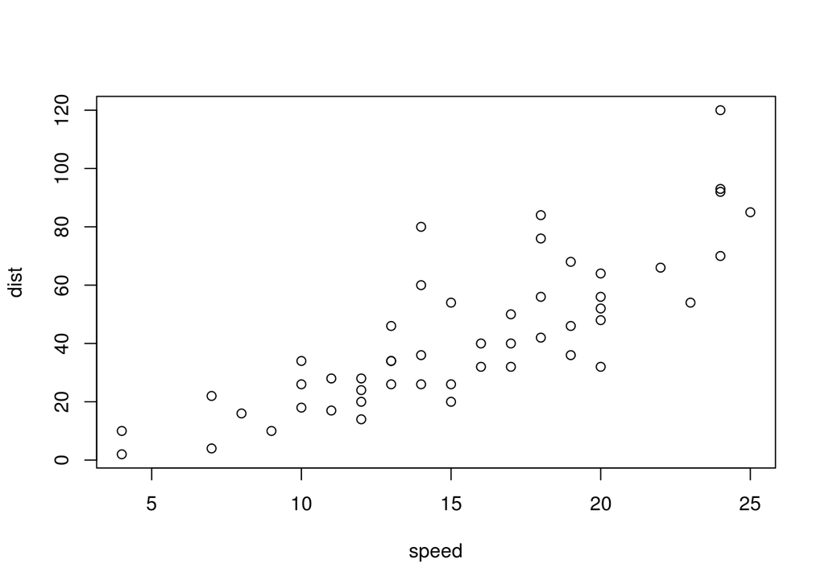

```r
plot(cars)
```